# E-Commerce Customer Data

# **Do Revenue of Customer who is special differ significantly from the people who don't?**

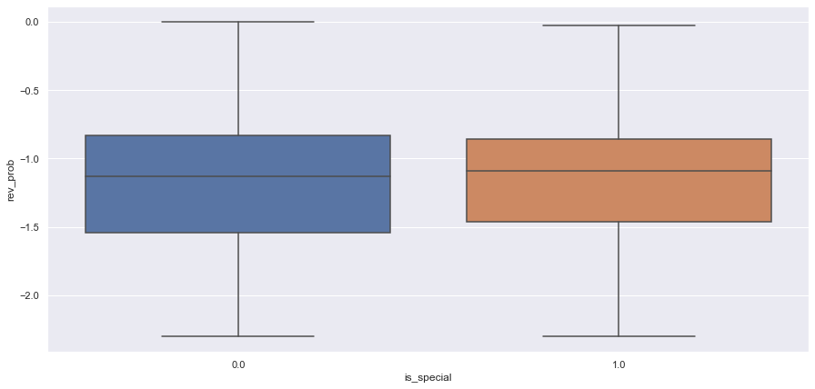

```python
plt.figure(figsize=(15,7))
sns.boxplot(x='is_special', y='rev_prob', data= df)
plt.show()
```

**Graph shows two means are nearly equal.**

**H0:Revenue of Special and Non-Special customers are same**

**H1:Revenue of Special and Non-Special customers are not same**

**T-Test**

```python
from scipy.stats import  ttest_ind
import scipy.stats as stats
```

```python
x = np.array(df[df.is_special == 1.0].rev_prob)
y = np.array(df[df.is_special == 0.0].rev_prob)
t, p_value  = stats.ttest_ind(x,y, axis = 0)
print('P_Value:', p_value)

if p_value < 0.05:  # Setting our significance level at 5%
    print('Rejecting Null Hypothesis.Revenue of Special and Non-Special customers are not same')
else:
    print('Fail to Reject Null Hypothesis.Revenue of Special and Non-Special customers are same')
```

```
P_Value: 0.6680868336778332
Fail to Reject Null Hypothesis.Revenue of Special and Non-Special customers are same
```

**There is no significant difference in revenue for special and non-special customer.**

# Do Revenue of Customer of different class of os_class differ significantly?

**H0:No of os_class does not affects revenue**

**H1:No of os_class affects revenue**

**Anova Test**

```python
x = np.array(df[df.os_class == 1].rev_prob)
y = np.array(df[df.os_class == 2].rev_prob)
z = np.array(df[df.os_class == 3].rev_prob)
f_stats,p_value=stats.f_oneway(x,y,z)
print('F_stats:',f_stats)
print('p_value:',p_value)
if p_value < 0.05:  # Setting our significance level at 5%
    print('Rejecting Null Hypothesis.No of os_class  affects revenue')
else:
    print('Fail to Reject Null Hypothesis.No of os_class does not affects revenue')
```

```
F_stats: 0.7840525026836408
p_value: 0.4566252676339154
Fail to Reject Null Hypothesis.No of os_class does not affects revenue
```

**Os_class does not significantly affecting Revenue**

# Do Revenue of different class of int_brws differ significantly?

**H0:No of int_brws does not affects revenue**

**H1:No of int_brws affects revenue**

```python
x = np.array(df[df.int_brws == 1.0].rev_prob)
y = np.array(df[df.int_brws == 2.0].rev_prob)
z = np.array(df[df.int_brws == 3.0].rev_prob)
f_stats,p_value=stats.f_oneway(x,y,z)
print('F_stats:',f_stats)
print('p_value:',p_value)
if p_value < 0.05:  # Setting our significance level at 5%
    print('Rejecting Null Hypothesis.No of int_brws  affects revenue')
else:
    print('Fail to Reject Null Hypothesis.No of int_brws does not affects revenue')
```

```
F_stats: 0.48218762678027466
p_value: 0.6174686419480633
Fail to Reject Null Hypothesis.No of int_brws does not affects revenue
```

# Do Revenue of different regions differ significantly?

**H0:No of region does not affects revenue**

**H1:No of region affects revenue**

```python
x = np.array(df[df.region == 1.0].rev_prob)
y = np.array(df[df.region == 2.0].rev_prob)
z = np.array(df[df.region == 3.0].rev_prob)
z1 = np.array(df[df.region == 4.0].rev_prob)
f_stats,p_value=stats.f_oneway(x,y,z,z1)
print('F_stats:',f_stats)
print('p_value:',p_value)
if p_value < 0.05:  # Setting our significance level at 5%
    print('Rejecting Null Hypothesis.Region affects revenue')
else:
    print('Fail to Reject Null Hypothesis.Region does not affects revenue')
```

```
F_stats: 1.2331157080612019
p_value: 0.29596996774864576
Fail to Reject Null Hypothesis.Region does not affects revenue
```

# Do Revenue of different traffic classes differ significantly?

**H0:Traffic_class does not affects revenue**

**H1:Traffic_class affects revenue**

```python
x = np.array(df[df.traffic_class == 1].rev_prob)
y = np.array(df[df.traffic_class == 2].rev_prob)
z = np.array(df[df.traffic_class == 3].rev_prob)
z1 = np.array(df[df.traffic_class == 4].rev_prob)
f_stats,p_value=stats.f_oneway(x,y,z,z1)
print('F_stats:',f_stats)
print('p_value:',p_value)
if p_value < 0.05:  # Setting our significance level at 5%
    print('Rejecting Null Hypothesis.Traffic_class affects revenue')
else:
    print('Fail to Reject Null Hypothesis.Traffic_class does not affects revenue')
```

```
F_stats: 10.921135698178988
p_value: 3.857550930062503e-07
Rejecting Null Hypothesis.Traffic_class affects revenue
```

**Traffic Significantly affects Revenue**

# Do Revenue of different Visitor type differs significantly?

**H0:Visitor Type does not affects revenue**

**H1:Visitor Type affects revenue**

```python
x = np.array(df[df.vis_type == 0].rev_prob)
y = np.array(df[df.vis_type == 1].rev_prob)
f_stats,p_value=stats.f_oneway(x,y)
print('F_stats:',f_stats)
print('p_value:',p_value)
if p_value < 0.05:  # Setting our significance level at 5%
    print('Rejecting Null Hypothesis.Visitor Type affects revenue')
else:
    print('Fail to Reject Null Hypothesis.Visitor Type  does not affects revenue')
```

```
F_stats: 4.954471185251594
p_value: 0.026081190629844812
Rejecting Null Hypothesis.Visitor Type affects revenue
```

**Visitor type affects revenue.**

# Do Revenue differs significantly for weekends?

**H0:Weekdays or not does not affects revenue**

**H1:Weekdays or not affects revenue**

```python
x = np.array(df[df.is_weekend == False].rev_prob)
y = np.array(df[df.is_weekend == True].rev_prob)
f_stats,p_value=stats.f_oneway(x,y)
print('F_stats:',f_stats)
print('p_value:',p_value)
if p_value < 0.05:  # Setting our significance level at 5%
    print('Rejecting Null Hypothesis.Weekdays or not affects revenue')
else:
    print('Fail to Reject Null Hypothesis.Weekdays or not  does not affects revenue')
```

```
F_stats: 5.119990894882017
p_value: 0.023707440724598815
Rejecting Null Hypothesis.Weekdays or not affects revenue
```

**Weekdays or not affects revenue**

**Removing categorical variables which are not significant.**

```python
drop_cat_col=['region','int_brws','os_class','is_special']
df.drop(drop_cat_col,axis=1,inplace=True)
```

```python
df['date'] = pd.to_numeric(pd.to_datetime(df['date']))
```

**Correlation Plot**

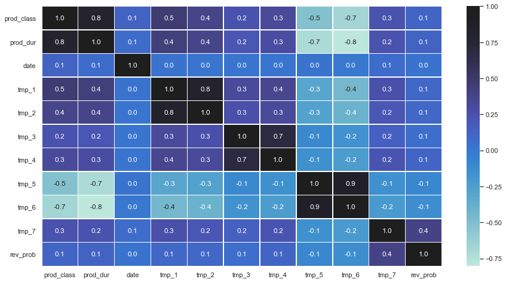

```python
plt.figure(figsize=(15,8))
sns.heatmap(df.corr(), annot=True, linewidths=.5, fmt= '.1f', center = 1 )  # heatmap
plt.show()
```

**None of the independent variables are correlated with target. Best correlation value is 0.4. Date gives zero coefficient.**

```python
df.drop('date',axis=1,inplace=True)
```

# Model Building

```python
def regression(X, Y, reg, param_grid, test_size=0.20):

    X_train, X_test, Y_train, Y_test = train_test_split(X, Y, test_size=test_size, random_state=42)


    reg = RandomizedSearchCV(reg,parameters, cv = 10,refit = True)
    reg.fit(X_train, Y_train)

    return X_train, X_test, Y_train, Y_test, reg
```

```python
def evaluation_metrics(X_train, X_test, Y_train, Y_test, reg):
    Y_pred_train = reg.best_estimator_.predict(X_train)
    Y_pred_test = reg.best_estimator_.predict(X_test)

    print("Best Parameters:",reg.best_params_)
    print('\n')
    print("Mean cross-validated score of the best_estimator : ", reg.best_score_)
    print('\n')
    MAE_train = metrics.mean_absolute_error(Y_train, Y_pred_train)
    MAE_test = metrics.mean_absolute_error(Y_test, Y_pred_test)
    print('MAE for training set is {}'.format(MAE_train))
    print('MAE for test set is {}'.format(MAE_test))
    print('\n')
    MSE_train = metrics.mean_squared_error(Y_train, Y_pred_train)
    MSE_test = metrics.mean_squared_error(Y_test, Y_pred_test)
    print('MSE for training set is {}'.format(MSE_train))
    print('MSE for test set is {}'.format(MSE_test))
    print('\n')
    RMSE_train = np.sqrt(metrics.mean_squared_error(Y_train, Y_pred_train))
    RMSE_test = np.sqrt(metrics.mean_squared_error(Y_test, Y_pred_test))
    print('RMSE for training set is {}'.format(RMSE_train))
    print('RMSE for test set is {}'.format(RMSE_test))
    print('\n')
    r2_train = metrics.r2_score(Y_train, Y_pred_train)
    r2_test = metrics.r2_score(Y_test, Y_pred_test)
    print("R2 value for train: ", r2_train)
    print("R2 value for test: ", r2_test)
```

```python
X = np.array(df.loc[:,df.columns!='rev_prob'])
Y = np.array(df.loc[:,df.columns=='rev_prob'])
```

```python
reg = LinearRegression()
parameters = {'fit_intercept':[True,False],'normalize':[True,False], 'copy_X':[True, False]}
X_train, X_test, Y_train, Y_test, linreg = regression(X, Y, reg, param_grid=parameters, test_size=0.20)
evaluation_metrics(X_train, X_test, Y_train, Y_test, reg = linreg)
```

```
Best Parameters: {'normalize': False, 'fit_intercept': True, 'copy_X': True}


Mean cross-validated score of the best_estimator :  0.13973189101171368


MAE for training set is 0.3846250033404425
MAE for test set is 0.39616627863439663


MSE for training set is 0.2194591101759357
MSE for test set is 0.23225416457024436


RMSE for training set is 0.46846463065629157
RMSE for test set is 0.48192755116328884


R2 value for train:  0.14952015700030774
R2 value for test:  0.14577054619416263
```

- **R2 is very low.As already seen,Most of the independent variables are not correlated with target.All Continuous variables are not significantly explains the dependent variables.**
- **Only Weekdays, Visitor Type, Traffic has effect on revenue.**

**We will check with other algorithms.**

# Decision Tree Regressor

```python
from sklearn.tree import DecisionTreeRegressor
reg = DecisionTreeRegressor()
parameters = {'max_depth':[5,6,7,8,9,10]}
X_train, X_test, Y_train, Y_test, DTreg = regression(X, Y, reg, param_grid=parameters, test_size=0.20)
evaluation_metrics(X_train, X_test, Y_train, Y_test, reg = DTreg)
```

```
Best Parameters: {'max_depth': 5}


Mean cross-validated score of the best_estimator :  0.09320963016845835


MAE for training set is 0.36858212702072696
MAE for test set is 0.4012627425829165


MSE for training set is 0.20366544175105009
MSE for test set is 0.23882020686322983


RMSE for training set is 0.4512930774464085
RMSE for test set is 0.4886923437739022


R2 value for train:  0.21072607655232622
R2 value for test:  0.12162068118751546
```

# **Random Forest**

```python
from sklearn.ensemble import RandomForestRegressor
reg = RandomForestRegressor(n_jobs=-1)
parameters = {'n_estimators':[10,15,20,25],'max_depth':[5,6,7,8,9,10]}
X_train, X_test, Y_train, Y_test, RFreg = regression(X, Y, reg, param_grid=parameters, test_size=0.20)
evaluation_metrics(X_train, X_test, Y_train, Y_test, reg = RFreg)
```

```
Best Parameters: {'n_estimators': 15, 'max_depth': 5}


Mean cross-validated score of the best_estimator :  0.1428628904272779


MAE for training set is 0.36527952448649487
MAE for test set is 0.3901042969593


MSE for training set is 0.19714469348177074
MSE for test set is 0.22529615141508597


RMSE for training set is 0.44400978984901984
RMSE for test set is 0.474653717372029


R2 value for train:  0.2359962280618776
R2 value for test:  0.17136207773075696
```

# Gradient Boosting Regressor

```python
from sklearn.ensemble import GradientBoostingRegressor
reg = GradientBoostingRegressor()
parameters = {'alpha':[0.01,0.001,0.0001],'n_estimators':[100,150,200],'max_depth':[3,5,7]}
X_train, X_test, Y_train, Y_test, XGreg = regression(X, Y, reg, param_grid=parameters, test_size=0.20)
evaluation_metrics(X_train, X_test, Y_train, Y_test, reg = XGreg)
```

```
Best Parameters: {'n_estimators': 100, 'max_depth': 3, 'alpha': 0.0001}


Mean cross-validated score of the best_estimator :  0.1299311261183771


MAE for training set is 0.3537704672934877
MAE for test set is 0.39214224668482006


MSE for training set is 0.18651427380119515
MSE for test set is 0.22857091697976709


RMSE for training set is 0.43187298341201563
RMSE for test set is 0.47809090869809173


R2 value for train:  0.277192775581408
R2 value for test:  0.1593175092088709
```

**All models are performing similarly.There is not much improvement in R2 value**

# **OLS Model With Forward Selection.**

```python
import statsmodels.formula.api as smf

def forward_selected(data, response):
    """Linear model designed by forward selection.

    Parameters:
    -----------
    data : pandas DataFrame with all possible predictors and response

    response: string, name of response column in data

    Returns:
    --------
    model: an "optimal" fitted statsmodels linear model
           with an intercept
           selected by forward selection
           evaluated by adjusted R-squared
    """
    remaining = set(data.columns)
    remaining.remove(response)
    selected = []
    current_score, best_new_score = 0.0, 0.0
    while remaining and current_score == best_new_score:
        scores_with_candidates = []
        for candidate in remaining:
            formula = "{} ~ {} + 1".format(response,
                                           ' + '.join(selected + [candidate]))
            score = smf.ols(formula, data).fit().rsquared_adj
            scores_with_candidates.append((score, candidate))
        scores_with_candidates.sort()
        best_new_score, best_candidate = scores_with_candidates.pop()
        if current_score < best_new_score:
            remaining.remove(best_candidate)
            selected.append(best_candidate)
            current_score = best_new_score
    formula = "{} ~ {} + 1".format(response,
                                   ' + '.join(selected))
    model = smf.ols(formula, data).fit()
    return model
```

```python
m=forward_selected(df,'rev_prob')
```

```python
m.summary()
```

OLS Regression Results

| Dep. Variable: | rev_prob | R-squared: | 0.150 |
| --- | --- | --- | --- |
| Model: | OLS | Adj. R-squared: | 0.148 |
| Method: | Least Squares | F-statistic: | 96.52 |
| Date: | Thu, 08 Apr 2021 | Prob (F-statistic): | 3.24e-130 |
| Time: | 19:03:37 | Log-Likelihood: | -2554.4 |
| No. Observations: | 3837 | AIC: | 5125. |
| Df Residuals: | 3829 | BIC: | 5175. |
| Df Model: | 7 |  |  |
| Covariance Type: | nonrobust |  |  |

|  | coef | std err | t | P>\|t\| | [0.025 | 0.975] |
| --- | --- | --- | --- | --- | --- | --- |
| Intercept | -1.4147 | 0.161 | -8.769 | 0.000 | -1.731 | -1.098 |
| traffic_class[T.2] | 0.0315 | 0.023 | 1.398 | 0.162 | -0.013 | 0.076 |
| traffic_class[T.3] | -0.0020 | 0.023 | -0.089 | 0.929 | -0.047 | 0.043 |
| traffic_class[T.4] | 0.0010 | 0.021 | 0.050 | 0.960 | -0.040 | 0.042 |
| tmp_7 | 0.1495 | 0.006 | 23.482 | 0.000 | 0.137 | 0.162 |
| tmp_6 | -0.2379 | 0.086 | -2.757 | 0.006 | -0.407 | -0.069 |
| tmp_4 | 0.0057 | 0.004 | 1.332 | 0.183 | -0.003 | 0.014 |
| tmp_1 | -0.0092 | 0.008 | -1.152 | 0.249 | -0.025 | 0.006 |

| Omnibus: | 163.447 | Durbin-Watson: | 2.016 |
| --- | --- | --- | --- |
| Prob(Omnibus): | 0.000 | Jarque-Bera (JB): | 175.648 |
| Skew: | -0.504 | Prob(JB): | 7.22e-39 |
| Kurtosis: | 2.714 | Cond. No. | 78.9 |

Warnings:  
[1] Standard Errors assume that the covariance matrix of the errors is correctly specified.

**There is no much improvemnt in forward selection method. The coefficeinets of few variables nearly equal to zero.**

**Lasso Regression to select important features**

```python
from sklearn.linear_model import Lasso
```

```python
X = np.array(df.loc[:,df.columns!='rev_prob'])
Y = np.array(df.loc[:,df.columns=='rev_prob'])
```

```python
X_train, X_test, Y_train, Y_test = train_test_split(X, Y, test_size=0.2, random_state=42)
lasso = Lasso(alpha=0.1)
lasso.fit(X_train,Y_train)
print ("Lasso model:", (lasso.coef_))
```

```
Lasso model: [ 0.          0.          0.         -0.          0.          0.
  0.          0.          0.         -0.         -0.          0.09131592]
```

**We can see lasso gives zero to most of the varibales, this is the reason we are getting poor fit.** .

**Making all preprocessings steps into one function**

```python
def pre_process(df):
    df.drop('date',axis=1,inplace=True)
    null_col=[]
    #missing value
    for i,j in enumerate(df.columns):
        if df.isnull().sum()[i]>0:
            df[j].fillna(df[j].median(),inplace=True)
            null_col.append(j)
        else:
            pass
    #setting index
    df.set_index(['sess_id'],inplace=True)
    #converting date
    #df['date']=pd.to_datetime(df['date'])
    #is_special
    df['is_special'].values[df['is_special'] > 0.5] = 1
    df['is_special'].values[df['is_special'] < 0.5] = 0
    #os_class
    df['os_class'].values[df['os_class'] > 3] = 3
    #int_brws
    df['int_brws'].values[df['int_brws'] > 2] = 3
    #traffic class
    df['traffic_class'].values[df['traffic_class'] > 3] = 4
    #region
    df['region'].values[df['region'] > 3] = 4
    #log tranformation
    col=['prod_class','prod_dur','tmp_1','tmp_2','tmp_3','tmp_4','tmp_5','tmp_6','tmp_7']
    for i in col:
        df[i] = np.log(df[i])
    df = df.replace([np.inf, -np.inf, -0], 0)
    #encoding
    df['vis_type']=labelencoder.fit_transform(df['vis_type'])
    #changing datatypes
    df['is_special']=df['is_special'].astype('category')
    df['os_class']=df['os_class'].astype('category')
    df['region']=df['region'].astype('category')
    df['traffic_class']=df['traffic_class'].astype('category')
    df['vis_type']=df['vis_type'].astype('category')
    df['is_weekend']=df['is_weekend'].astype('category')
    df['int_brws']=df['int_brws'].astype('category')
    #statistical insignificant column
    drop_cat_col=['region','int_brws','os_class','is_special']
    df.drop(drop_cat_col,axis=1,inplace=True)
    return df
```

**Random Forest performs better compared to other models.**

```python
X = np.array(df.loc[:,df.columns!='rev_prob'])
Y = np.array(df.loc[:,df.columns=='rev_prob'])
reg = RandomForestRegressor(n_jobs=-1)
parameters = {'n_estimators':[10,15,20,25],'max_depth':[5,6,7,8,9,10]}
X_train, X_test, Y_train, Y_test, RFreg = regression(X, Y, reg, param_grid=parameters, test_size=0.20)
evaluation_metrics(X_train, X_test, Y_train, Y_test, reg = RFreg)
```

```
Best Parameters: {'n_estimators': 25, 'max_depth': 6}


Mean cross-validated score of the best_estimator :  0.14275505708825764


MAE for training set is 0.3583835074035989
MAE for test set is 0.38826291289998816


MSE for training set is 0.18952460270115098
MSE for test set is 0.2238424611583626


RMSE for training set is 0.43534423471679395
RMSE for test set is 0.47311992259718105


R2 value for train:  0.2655267114651386
R2 value for test:  0.17670874196087505
```

```python
test=pd.read_csv('test.csv')
train=pd.read_csv('train.csv')
```

**Predicting Test Data**

```python
df_1=pre_process(test)
```

```python
df_1.head()
```

| sess_id | prod_class | prod_dur | traffic_class | vis_type | is_weekend | tmp_1 | tmp_2 | tmp_3 | tmp_4 | tmp_5 | tmp_6 | tmp_7 |
| --- | --- | --- | --- | --- | --- | --- | --- | --- | --- | --- | --- | --- |
| Tr-15743 | 3.367296 | -1.214284 | 4 | 1 | True | 0.136132 | 0.581455 | 0.000000 | -0.894794 | -1.845211 | -1.775442 | -0.932078 |
| Tr-15744 | 1.945910 | -1.442087 | 4 | 0 | False | -0.207639 | 0.322606 | 0.000000 | -0.906605 | -1.865367 | -1.799877 | -0.860432 |
| Tr-15745 | 2.772589 | -1.659469 | 4 | 0 | False | 0.136132 | -1.413941 | 0.693147 | -1.060767 | -1.828828 | -1.731048 | -0.910067 |
| Tr-15746 | 3.258097 | -0.199235 | 4 | 0 | True | -0.207639 | 0.395154 | 0.000000 | -1.826509 | -1.773108 | -1.611871 | -1.137812 |
| Tr-15747 | 1.098612 | -1.076923 | 4 | 1 | False | -0.735707 | -0.312553 | 0.693147 | -0.895364 | -1.708364 | -1.836386 | -0.949669 |

```python
pred_test = RFreg.best_estimator_.predict(df_1)
```

**Creating Predicted File**

```python
df_1['predicted'] = pred_test
df_1['ID'] = df_1.index
output=df_1[['ID','predicted']]
output.to_csv("results.csv",index=False)
```